# Estatística no R

Maurício Bueno

2021-12-05

# Carregamento dos pacotes e arquivos

```r
library(tidyverse)
library(psych)
library(pander)
# saveRDS(dataset,"dataset.rds")
# saveRDS(rwas,"rwas.rds")
# saveRDS(big_five,"big_five.rds")
# saveRDS(big_five_BR,"big_five_BR.rds")

dataset <- readRDS("dataset.rds")
rwas <- readRDS("rwas.rds")
big_five <- readRDS("big_five.rds")
big_five_BR <- readRDS("big_five_BR.rds")
```

# Análises dos efeitos do pertencimento a grupos

Em muitas pesquisas, o interesse recai sobre os efeitos de grupo. Nesses casos, investiga-se se o fato das pessoas perteceram a um grupo produz algum efeito em alguma variável psicológica. Por exemplo, qual é o efeito de sexo (masculino ou feminino) na variável inteligência? Qual é o efeito de um programa de desenvolvimento da inteligência emocional (grupos controle e experimental) sobre a qualidade de vida? Qual o efeito do país de origem (A, B, C) no desempenho escolar? As análises estatísticas que normalmente são usadas nesses estudos são as seguintes:

Teste t Análise de variância de duas vias (ANOVA) Análise de varância univariada Análise de variância multivariada (MANOVA) - Anova Fatorial Análise de Covariância (ANCOVA) Análise Multivariada de Covariância (MANCOVA) Análise de variância por medidas repetidas

# Teste t

Quando queremos comparar uma variável do nosso banco de dados com os dados constantes na literatura (por exemplo, as pontuações em depressão da nossa amostra com a média da população), usamos o **teste t para uma amostra**. Como exemplo, vamos usar o banco de dados `big_five_BR`, para investigar se as pontuações em neuroticismo dos brasileiros é significativamente diferentes da média encontrada nos diversos países em que a escala foi aplicada. Para isso, começamos investigando se a distribuição das pontuações é ao menos próxima da distribuição normal.

### Análise do pressuposto de normalidade

O ideal é empregar o teste de Shapiro-Wilk para a verificação da normalidade da variável que se quer testar. No entanto, esse teste, geralmente, resulta em diferença significativa, mesmo quando a distribuição é muito próxima da normal. Por isso, costuma-se usar parâmetros um pouco mais flexíveis, que são os índices de assimetria e curtose.

```r
shapiro.test(big_five_BR$neur)
```

```
##
##  Shapiro-Wilk normality test
##
## data:  big_five_BR$neur
## W = 0.97895, p-value = 0.009365
```

```r
skew(big_five_BR$neur,na.rm = TRUE)
```

```
## [1] -0.3942969
```

```r
kurtosi(big_five_BR$neur,na.rm = TRUE)
```

```
## [1] -0.4525034
```

Então, podemos considerar que os dados são próximos da distribuição normal pois, os dados de assimetria e curtose estão dentro do intervalo de -0,5 e 0,5 (Maroco, 2003). Assim, prosseguimos com a análise e vamos calcular as médias da amostra completa (banco de dados `big_five`), que servirá de referência.

### Média da amostra completa (referência)

```r
# seleção de um subset do datarame big_five somente com os participantes NÃO-BRASILEIROS na variável neur
média_neur <- big_five %>%
  filter(!país == "BR") %>%
  select("neur")

# cálculo da média dos participantes NÃO-BRASILEIROS em neur
# Esse resultado será utilizado como referência no t-teste
round(mean(média_neur$neur, na.rm = TRUE),digits = 2)
```

```
## [1] 3.09
```

# Teste-t para uma amostra

```r
t.test(                # t.test é o comando do stats
  big_five_BR$neur,    # localização da variável neur em brasileiros
  mu = 3.09)           # valor de referência, calculado anteriormente
```

```
##
##  One Sample t-test
##
## data:  big_five_BR$neur
## t = 4.0006, df = 174, p-value = 9.331e-05
## alternative hypothesis: true mean is not equal to 3.09
## 95 percent confidence interval:
##  3.214347 3.456510
## sample estimates:
## mean of x
##  3.335429
```

O resultado foi estatísticamente significativo (p < 0,05), indicando que a média dos brasileiros em neuroticismo é maior do que a média de outros países que compõem a amostra.

### Representação Gráfica

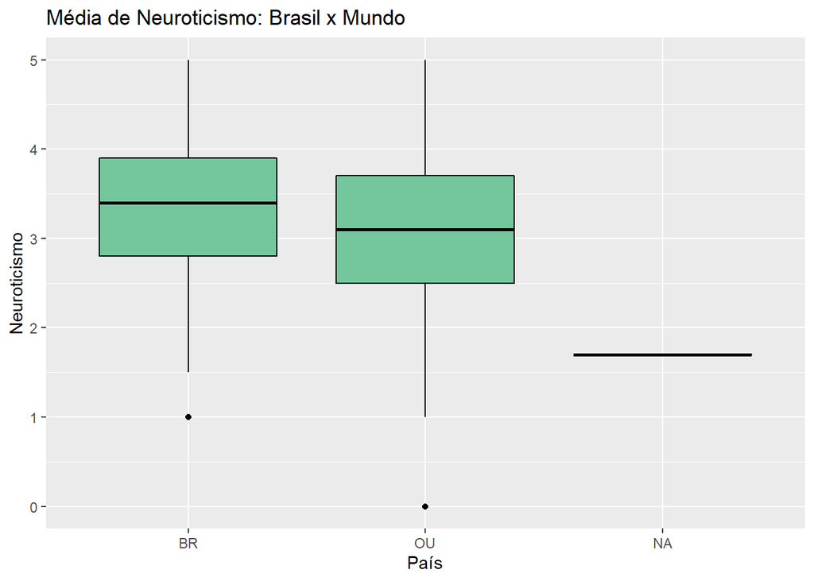

```r
big_five %>% mutate(Brasil = ifelse(país == "BR","BR","OU")) %>%
  ggplot(aes(x = Brasil, y = neur)) +
  geom_boxplot(color = "black", fill = "#74c69d") +
  labs(title = "Média de Neuroticismo: Brasil x Mundo",
       x = "País",
       y = "Neuroticismo")
```

# Teste-t para amostras independentes

Essa análise estatística se aplica à comparação das médias de dois grupos em que os participantes ou estão em um grupo ou estão no outro, não sendo possível estar nos dois grupos ao mesmo tempo. Por isso a denominação de **amostras independentes**. Para isso, vamos usar o dataframe big_five_BR e analisar o efeito de gênero (sexo, na verdade, pois só consideraremos as categorias **masculino** e **feminino**) nos cinco grandes fatores de personalidade.

### Preparação do banco de dados e carregamento dos pacotes

```r
# primeiro passo: trasnformar a categoria "outros" em NA
big_five_BR$gênero[big_five_BR$gênero == "Outro"] <- NA
```

### Análise dos pressupostos

```r
# verificação da normalidade dos dados, separado por grupos.
# vamos usar o pacote RVAideMemoire

## RVAideMemoire::byf.shapiro(formula = extr ~ gênero, data = big_five_nona)
### a função anterior não está funcionando e não consegui descobrir por quê.
### então, fui para a observação dos índices de assimetria e curtose

### skewness()

skew(big_five_BR$extr, na.rm = TRUE)
```

```
## [1] 0.3938411
```

```r
skew(big_five_BR$neur, na.rm = TRUE)
```

```
## [1] -0.3942969
```

```r
skew(big_five_BR$amab, na.rm = TRUE)
```

```
## [1] -0.3359957
```

```r
skew(big_five_BR$cons, na.rm = TRUE)
```

```
## [1] 0.06391432
```

```r
skew(big_five_BR$aber, na.rm = TRUE)
```

```
## [1] -0.3763966
```

```r
### kurtosis()

kurtosi(big_five_BR$extr, na.rm = TRUE)
```

```
## [1] -0.6390533
```

```r
kurtosi(big_five_BR$neur, na.rm = TRUE)
```

```
## [1] -0.4525034
```

```r
kurtosi(big_five_BR$amab, na.rm = TRUE)
```

```
## [1] -0.3126487
```

```r
kurtosi(big_five_BR$cons, na.rm = TRUE)
```

```
## [1] -0.7392289
```

```r
kurtosi(big_five_BR$aber, na.rm = TRUE)
```

```
## [1] -0.4208564
```

```r
# verificação da homogeneidade das variâncias
# Teste de Levene usando o pacote car

car::leveneTest(extr ~ gênero, big_five_BR, center=mean)
```

```
## Levene's Test for Homogeneity of Variance (center = mean)
##        Df F value Pr(>F)
## group   1  1.1734 0.2802
##       170
```

```r
car::leveneTest(neur ~ gênero, big_five_BR, center=mean)
```

```
## Levene's Test for Homogeneity of Variance (center = mean)
##        Df F value Pr(>F)
## group   1  0.3454 0.5575
##       170
```

```r
car::leveneTest(amab ~ gênero, big_five_BR, center=mean)
```

```
## Levene's Test for Homogeneity of Variance (center = mean)
##        Df F value Pr(>F)
## group   1   0.443 0.5066
##       170
```

```r
car::leveneTest(cons ~ gênero, big_five_BR, center=mean)
```

```
## Levene's Test for Homogeneity of Variance (center = mean)
##        Df F value Pr(>F)
## group   1  0.0049 0.9443
##       170
```

```r
car::leveneTest(aber ~ gênero, big_five_BR, center=mean)
```

```
## Levene's Test for Homogeneity of Variance (center = mean)
##        Df F value Pr(>F)
## group   1  0.0977 0.7549
##       170
```

```r
## OBS: Por default, o teste realizado pelo pacote car tem como base a mediana, que é mais robusto, mas, para ficar igual ao SPSS, mudamos para a média, por isso o argumento center=mean.
## Em todas as variáveis as variâncias foram homogêneas

t_extr <- t.test(extr ~ gênero, big_five_BR, var.equal = TRUE)
t_neur <- t.test(neur ~ gênero, big_five_BR, var.equal = TRUE)
t_amab <- t.test(amab ~ gênero, big_five_BR, var.equal = TRUE)
t_cons <- t.test(cons ~ gênero, big_five_BR, var.equal = TRUE)
t_aber <- t.test(aber ~ gênero, big_five_BR, var.equal = TRUE)
```

### Apresentação dos resultados em uma tabela

```r
data.frame(Variável = c("Extroversão","Neuroticismo","Amabilidade",
                        "Conscienciosidade","Abertura"),
           t = c(round(t_extr$statistic,digits = 3),
                 round(t_neur$statistic,digits = 3),
                 round(t_amab$statistic,digits = 3),
                 round(t_cons$statistic,digits = 3),
                 round(t_aber$statistic,digits = 3)),
           gl = c(t_extr$parameter,
                  t_neur$parameter,
                  t_amab$parameter,
                  t_cons$parameter,
                  t_aber$parameter),
           p = c(round(t_extr$p.value,digits = 3),
                 round(t_neur$p.value,digits = 3),
                 round(t_amab$p.value,digits = 3),
                 round(t_cons$p.value,digits = 3),
                 round(t_aber$p.value,digits = 3))) %>% pander::pander()
```

| Variável | t | gl | p |
| --- | --- | --- | --- |
| Extroversão | -0.855 | 170 | 0.394 |
| Neuroticismo | -1.867 | 170 | 0.064 |
| Amabilidade | -2.106 | 170 | 0.037 |
| Conscienciosidade | 0.172 | 170 | 0.864 |
| Abertura | 1.375 | 170 | 0.171 |

Juntamente com esse resultado, é necessário apresentar as estatísticas descritivas. Então, a tabela poderia ficar assim.

```r
## Usando a função tableby do pacote arsenal
arsenal::tableby(gênero ~ extr + neur + amab + cons + aber,
                 data = big_five_BR,
                 test = FALSE) %>%
  summary(text = TRUE)
```

```
##
##
## |             | Masculino (N=89) | Feminino (N=83) | Total (N=172) |
## |:------------|:----------------:|:---------------:|:-------------:|
## |extr         |                  |                 |               |
## |-  Mean (SD) |  2.545 (0.893)   |  2.665 (0.950)  | 2.603 (0.920) |
## |-  Range     |  1.100 - 4.700   |  1.000 - 4.500  | 1.000 - 4.700 |
## |neur         |                  |                 |               |
## |-  Mean (SD) |  3.228 (0.793)   |  3.455 (0.804)  | 3.338 (0.804) |
## |-  Range     |  1.000 - 4.800   |  1.500 - 5.000  | 1.000 - 5.000 |
## |amab         |                  |                 |               |
## |-  Mean (SD) |  3.378 (0.748)   |  3.612 (0.709)  | 3.491 (0.737) |
## |-  Range     |  1.500 - 4.900   |  1.500 - 5.000  | 1.500 - 5.000 |
## |cons         |                  |                 |               |
## |-  Mean (SD) |  3.035 (0.681)   |  3.017 (0.690)  | 3.026 (0.683) |
## |-  Range     |  1.500 - 4.600   |  1.700 - 4.500  | 1.500 - 4.600 |
## |aber         |                  |                 |               |
## |-  Mean (SD) |  4.137 (0.608)   |  4.007 (0.630)  | 4.074 (0.620) |
## |-  Range     |  2.400 - 5.000   |  2.200 - 5.000  | 2.200 - 5.000 |
```

### Representação gráfica

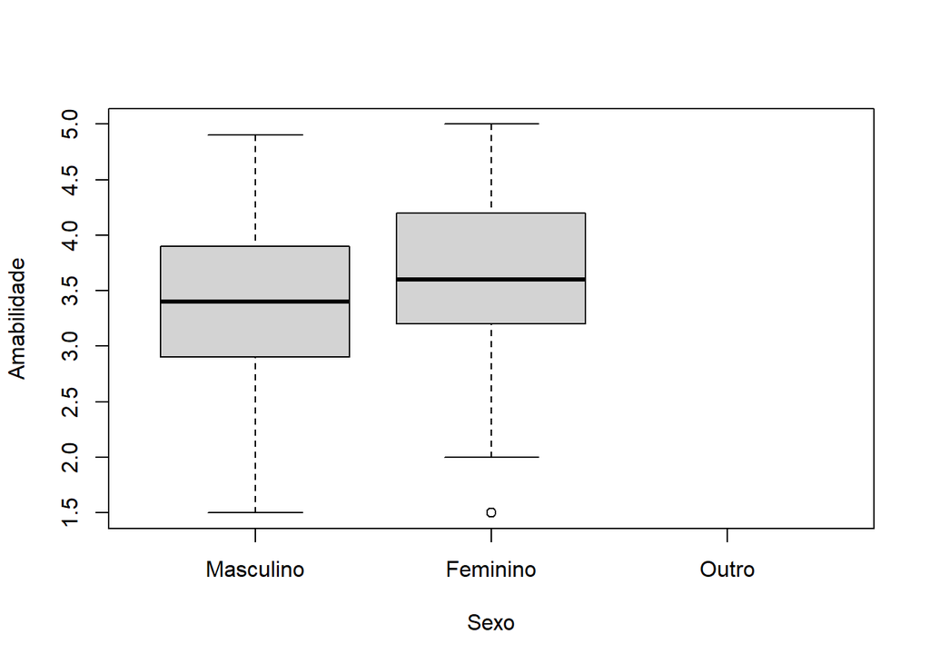

```r
# usando o graphics (base do R)
boxplot(amab ~ gênero, big_five_BR, ylab = "Amabilidade", xlab = "Sexo")
```

# Teste-t para amostras pareadas

Muitas vezes, os pesquisadores estão interessados em comparar o mesmo grupo de pessoas em duas situações diferentes, como por exemplo, antes e após alguma intervenção (pré e pós-teste). Como o grupo de pessoas é o mesmo, diz-se que o teste-t é para **amostras pareadas**. Para realizar essa análise, vamos utilizar um **banco de dados fictício** que contém duas supostas medidas de habilidades em leitura, uma realizada antes de um programa de intervenção para estimulação da leitura, e uma realizada após o programa.

```r
# Criação de um dataframe para análise de dados pareados
df <- data.frame(id = paste("s",1:30,sep=""),
                 pre_teste = rnorm(30, mean = 5.14, sd = 1.23),
                 pos_teste = rnorm(30, mean = 6.78, sd = 0.93))
```

### Análise dos pressupostos

```r
# verificação da normalidade
## O pressuposto é que a diferença entre as variáveis seja normal
## então, o primeiro passo é calcular as diferenças e inserir como uma variável no dataframe df

df$dif <- df$pos_teste - df$pre_teste

### teste de Shapiro-Wilk para normalidade
shapiro.test(df$dif)
```

```
##
##  Shapiro-Wilk normality test
##
## data:  df$dif
## W = 0.97714, p-value = 0.7455
```

```r
### Testes de assimetria e curtose
skew(df$dif)
```

```
## [1] 0.08422662
```

```r
kurtosi(df$dif)
```

```
## [1] -0.953722
```

### Teste-t para amostras pareadas

```r
t_par <- t.test(df$pos_teste,df$pre_teste,paired = TRUE)
```

### Apresentação dos resultados em uma tabela

```r
summary(df$pre_teste)
```

```
##    Min. 1st Qu.  Median    Mean 3rd Qu.    Max.
##   3.404   4.583   5.140   5.309   5.965   7.594
```

```r
summary(df$pos_teste)
```

```
##    Min. 1st Qu.  Median    Mean 3rd Qu.    Max.
##   5.131   5.675   6.266   6.421   7.071   8.081
```

```r
desc_ <- describe(df$pre_teste)

data.frame(Variáves = c("Pré-teste",
                          "Pós-teste"),
           Média = c(round(mean(df$pre_teste,na.rm=TRUE),digits=2),
                     round(mean(df$pos_teste,na.rm=TRUE),digits=2)),
           "Desv. Padrão" = c(round(sd(df$pre_teste,na.rm=TRUE),digits=2),
                              round(sd(df$pos_teste,na.rm=TRUE),digits=2))) %>%
  pander::pander()
```

| Variáves | Média | Desv..Padrão |
| --- | --- | --- |
| Pré-teste | 5.31 | 1.09 |
| Pós-teste | 6.42 | 0.85 |

### Representação gráfica

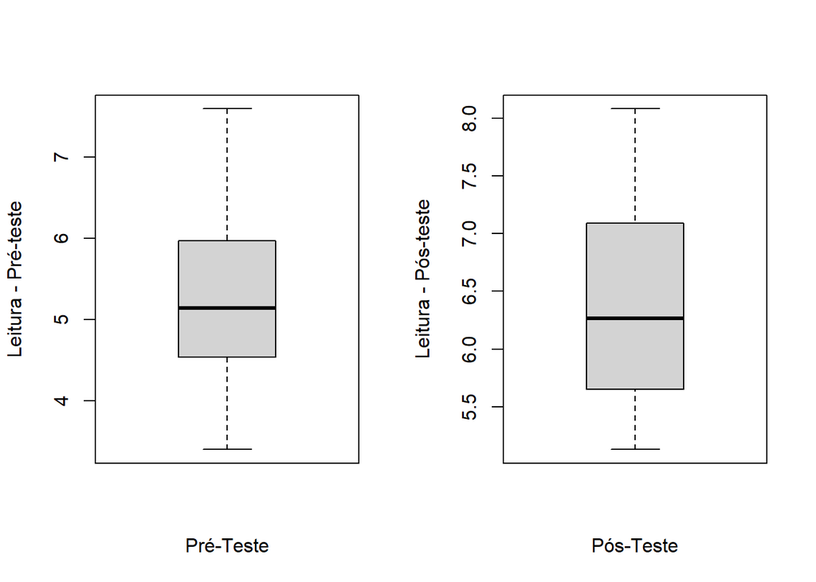

```r
par(mfrow=c(1,2))
boxplot(df$pre_teste, ylab="Leitura - Pré-teste", xlab="Pré-Teste")
boxplot(df$pos_teste, ylab="Leitura - Pós-teste", xlab="Pós-Teste")
```

```r
par(mfrow=c(1,1))
```

# Análise de Variância

O teste-t apresenta uma limitação importante, que é a de só conseguir comparar **duas** categorias de uma variável. Para superar essa limitação e podermos comparar mais de duas categorias de uma variável é preciso utilizar uma Análise de Variância (ANOVA).

# ANOVA de uma via

```r
# seleção de um subset do banco de dados com
nrow(rwas)
```

```
## [1] 9881
```

### Verificação dos pressupostos

```r
# verificação da normalidade dos dados
## A maioria dos autores recomenda que a normalidade seja avaliada por grupo e não como um todo.
RVAideMemoire::byf.shapiro(rv ~ education, rwas)
```

```
##
##  Shapiro-Wilk normality tests
##
## data:  rv by education
##
##                            W   p-value
## Less than high school 0.9227 < 2.2e-16 ***
## High school           0.9089 < 2.2e-16 ***
## University degree     0.8497 < 2.2e-16 ***
## Graduate degree       0.7470 < 2.2e-16 ***
## ---
## Signif. codes:  0 '***' 0.001 '**' 0.01 '*' 0.05 '.' 0.1 ' ' 1
```

```r
## Os resultados, como de costume, deram significativos, ou seja, diferente de uma distribuição normal. Por isso, vamos usar um critério mais permissivo: as análises de assimetria e curtose.

rwas %>%
  filter(education=="Less than high school") %>%
  select("auth") %>%
  skew()
```

```
## [1] -0.08525783
```

```r
rwas %>% filter(education=="High school") %>% dplyr::select("auth") %>% skew()
```

```
## [1] 0.1621545
```

```r
rwas %>% filter(education=="University degree") %>% dplyr::select("auth") %>% skew()
```

```
## [1] 0.2454205
```

```r
rwas %>% filter(education=="Graduate degree") %>% dplyr::select("auth") %>% skew()
```

```
## [1] -0.458173
```

```r
rwas %>% filter(education=="Less than high school") %>% dplyr::select("auth") %>% kurtosi()
```

```
##     auth
## 8.441169
```

```r
rwas %>% filter(education=="High school") %>% dplyr::select("auth") %>% kurtosi()
```

```
##     auth
## 4.678227
```

```r
rwas %>% filter(education=="University degree") %>% dplyr::select("auth") %>% kurtosi()
```

```
##     auth
## 3.945879
```

```r
rwas %>% filter(education=="Graduate degree") %>% dplyr::select("auth") %>% kurtosi()
```

```
##     auth
## 10.61457
```

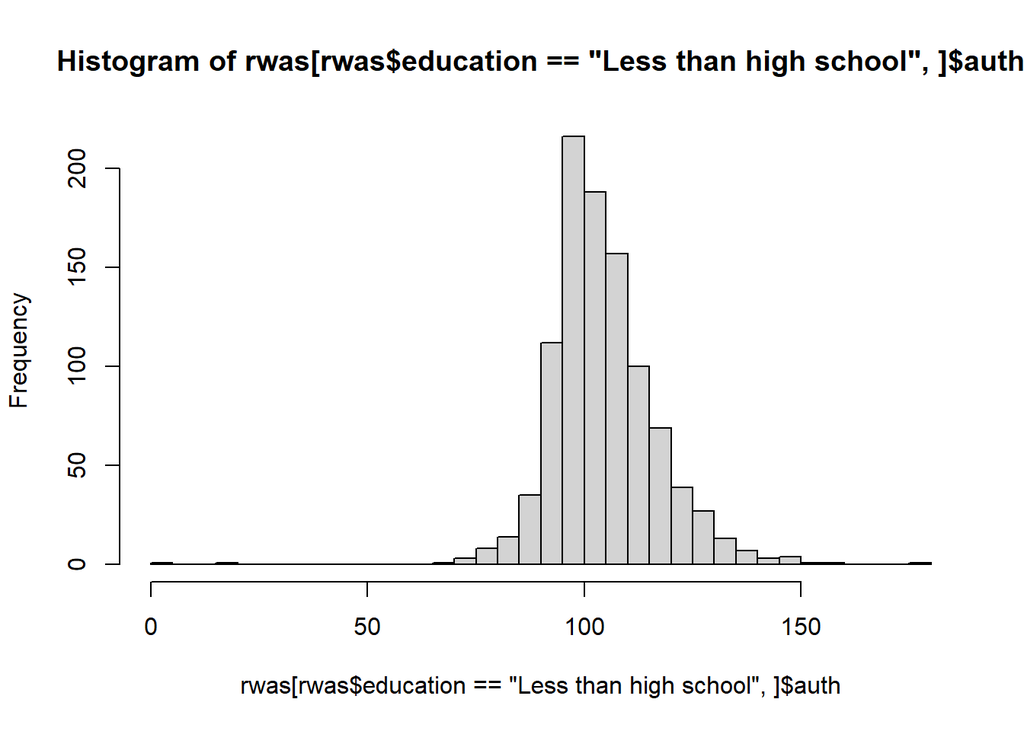

```r
hist(rwas[rwas$education=="Less than high school",]$auth,breaks = 30)
```

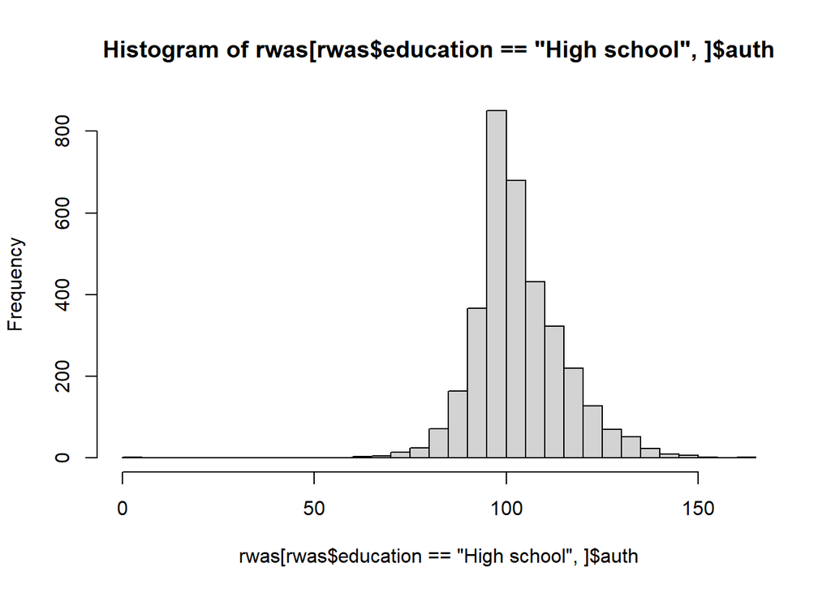

```r
hist(rwas[rwas$education=="High school",]$auth,breaks = 30)
```

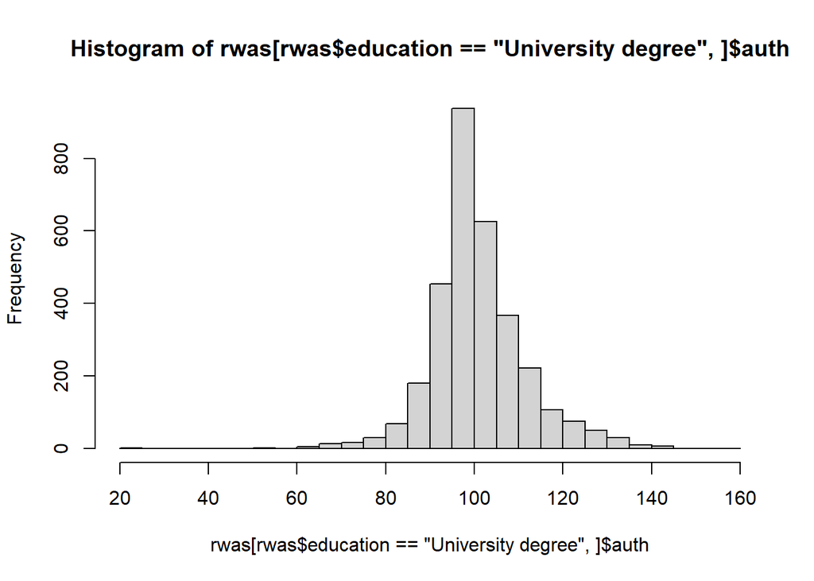

```r
hist(rwas[rwas$education=="University degree",]$auth,breaks = 30)
```

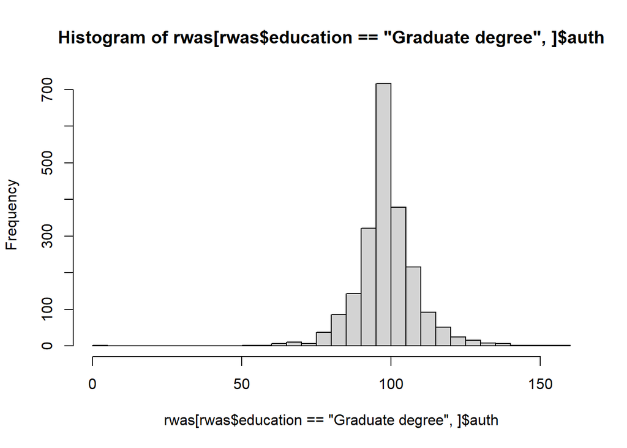

```r
hist(rwas[rwas$education=="Graduate degree",]$auth,breaks = 30)
```

```r
# verificação da homogeneidade das variâncias
car::leveneTest(auth ~ education, rwas, center = mean)
```

```
## Levene's Test for Homogeneity of Variance (center = mean)
##         Df F value    Pr(>F)
## group    3  32.219 < 2.2e-16 ***
##       9775
## ---
## Signif. codes:  0 '***' 0.001 '**' 0.01 '*' 0.05 '.' 0.1 ' ' 1
```

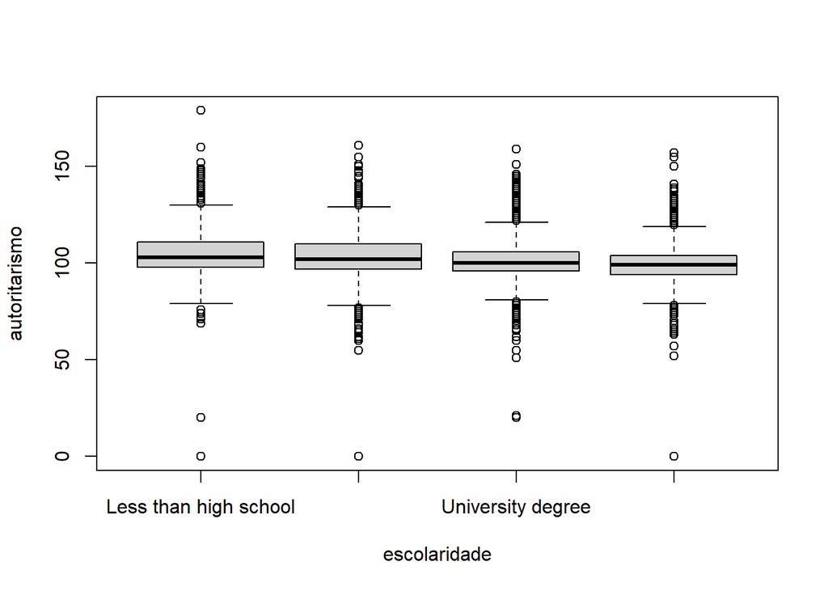

```r
# verificação da presença de outliers

## usando boxplot
boxplot(auth ~ education, rwas, ylab = "autoritarismo", xlab = "escolaridade")
```

```r
## usando identify_outliers
rwas %>%
  select(education, auth) %>%
  group_by(education) %>%
  rstatix::identify_outliers(auth) %>% knitr::kable()
```

| education | auth | is.outlier | is.extreme |
| --- | --- | --- | --- |
| Less than high school | 146 | TRUE | FALSE |
| Less than high school | 131 | TRUE | FALSE |
| Less than high school | 139 | TRUE | FALSE |
| Less than high school | 0 | TRUE | TRUE |
| Less than high school | 134 | TRUE | FALSE |
| Less than high school | 135 | TRUE | FALSE |
| Less than high school | 76 | TRUE | FALSE |
| Less than high school | 140 | TRUE | FALSE |
| Less than high school | 147 | TRUE | FALSE |
| Less than high school | 144 | TRUE | FALSE |
| Less than high school | 136 | TRUE | FALSE |
| Less than high school | 74 | TRUE | FALSE |
| Less than high school | 131 | TRUE | FALSE |
| Less than high school | 134 | TRUE | FALSE |
| Less than high school | 131 | TRUE | FALSE |
| Less than high school | 72 | TRUE | FALSE |
| Less than high school | 139 | TRUE | FALSE |
| Less than high school | 152 | TRUE | TRUE |
| Less than high school | 131 | TRUE | FALSE |
| Less than high school | 133 | TRUE | FALSE |
| Less than high school | 137 | TRUE | FALSE |
| Less than high school | 133 | TRUE | FALSE |
| Less than high school | 139 | TRUE | FALSE |
| Less than high school | 141 | TRUE | FALSE |
| Less than high school | 131 | TRUE | FALSE |
| Less than high school | 131 | TRUE | FALSE |
| Less than high school | 149 | TRUE | FALSE |
| Less than high school | 131 | TRUE | FALSE |
| Less than high school | 20 | TRUE | TRUE |
| Less than high school | 160 | TRUE | TRUE |

[output cut: 493 more lines]

### Realização da ANOVA de uma via

```r
# Criação do modelo usando a função aov do pacote stats (Base do R)
anova_auth <- aov(auth ~ education, rwas)

# visualização dos resultados
summary(anova_auth)
```

```
##               Df  Sum Sq Mean Sq F value Pr(>F)
## education      3   38682   12894     102 <2e-16 ***
## Residuals   9775 1235734     126
## ---
## Signif. codes:  0 '***' 0.001 '**' 0.01 '*' 0.05 '.' 0.1 ' ' 1
## 102 observations deleted due to missingness
```

```r
# Testes de post-hoc
# post-hocs permitidos: "hsd" (Tukey's HSD), "bonferroni", "lsd", "scheffe", "duncan"
DescTools::PostHocTest(anova_auth, method = "hsd", conf.level = 0.95)
```

```
##
##   Posthoc multiple comparisons of means : Tukey HSD
##     95% family-wise confidence level
##
## $education
##                                              diff    lwr.ci      upr.ci   pval
## High school-Less than high school       -1.128433 -2.165706 -0.09116049 0.0267
## University degree-Less than high school -3.550863 -4.596796 -2.50493131 <2e-16
## Graduate degree-Less than high school   -5.822985 -6.930659 -4.71531191 <2e-16
## University degree-High school           -2.422430 -3.131166 -1.71369426 <2e-16
## Graduate degree-High school             -4.694552 -5.491592 -3.89751193 <2e-16
## Graduate degree-University degree       -2.272122 -3.080399 -1.46384454 <2e-16
##
## High school-Less than high school       *
## University degree-Less than high school ***
## Graduate degree-Less than high school   ***
## University degree-High school           ***
## Graduate degree-High school             ***
## Graduate degree-University degree       ***
##
## ---
## Signif. codes:  0 '***' 0.001 '**' 0.01 '*' 0.05 '.' 0.1 ' ' 1
```

### Apresentação dos dados em tabela

```r
# usando a função tableby() do pacote arsenal
# muito simples, mas a tabela fica muito larga e não cabe na página
one_way_anova_tab <- arsenal::tableby(education ~ auth,
                                      digits = 1,
                                      test = FALSE,
                                      rwas)

summary(one_way_anova_tab,text=TRUE)
```

```
##
##
## |             | Less than high school (N=1001) | High school (N=3447) | University degree (N=3208) | Graduate degree (N=2123) | Total (N=9779) |
## |:------------|:------------------------------:|:--------------------:|:--------------------------:|:------------------------:|:--------------:|
## |auth         |                                |                      |                            |                          |                |
## |-  Mean (SD) |          105.0 (12.6)          |     103.8 (11.8)     |        101.4 (10.8)        |       99.1 (10.3)        |  102.1 (11.4)  |
## |-  Range     |          0.0 - 179.0           |     0.0 - 161.0      |        20.0 - 159.0        |       0.0 - 157.0        |  0.0 - 179.0   |
```

```r
# criando uma dataframe

data.frame(Escolaridade = c("Less than high school",
                            "High school",
                            "University degree",
                            "Graduate degree"),
           Média =
             c(round(mean(rwas[rwas$education == "Less than high school",]$auth, na.rm = TRUE),digits=1),
               round(mean(rwas[rwas$education == "High school",]$auth, na.rm = TRUE),digits=1),
               round(mean(rwas[rwas$education == "University degree",]$auth, na.rm = TRUE),digits=1),
               round(mean(rwas[rwas$education == "Graduate degree",]$auth, na.rm = TRUE),digits=1)),
           DesvPad =
             c(round(sd(rwas[rwas$education == "Less than high school",]$auth, na.rm = TRUE),digits=1),
               round(sd(rwas[rwas$education == "High school",]$auth, na.rm = TRUE),digits=1),
               round(sd(rwas[rwas$education == "University degree",]$auth, na.rm = TRUE),digits=1),
               round(sd(rwas[rwas$education == "Graduate degree",]$auth, na.rm = TRUE),digits=1))) %>%
  pander()
```

| Escolaridade | Média | DesvPad |
| --- | --- | --- |
| Less than high school | 105 | 12.6 |
| High school | 103.8 | 11.8 |
| University degree | 101.4 | 10.8 |
| Graduate degree | 99.1 | 10.3 |

### Representação gráfica

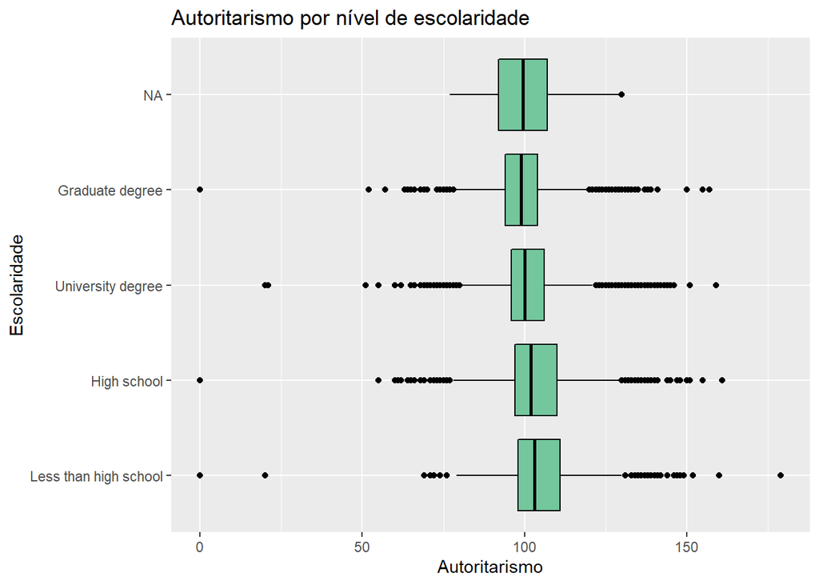

```r
ggplot(rwas, aes(x = education, y = auth)) +
  geom_boxplot(color = "black", fill = "#74c69d") +
  labs(title = "Autoritarismo por nível de escolaridade",
       x = "Escolaridade",
       y = "Autoritarismo") +
  coord_flip()
```

# ANOVA de medidas repetidas

A ANOVA de uma via permite comparar 3 ou mais grupos (por exemplo, níveis de escolaridade) quanto a uma variável (por exemplo, autoritarismo), como vimos no exemplo anterior. No entanto, essa análise se aplica a somente uma variável dependente e a grupos independentes. Se quisermos realizar uma comparação de grupos pareados ao longo de duas ou mais medidas, teremos que usar uma ANOVA de medidas repetidas. Para isso precisaremos instalar o pacote `ez`, que facilita a realização dessa análise.

### Instalação de pacotes

```r
# install.packages("ez")
library(ez)
```

### Geração de um banco de dados

Para realizar essa análise, vamos gerar um **banco de dados fictício** em que a variável *id* identifica os sujeitos (N = 100), e as variáveis de *v1* a *v5* representam as medidas repetidas. Nesse caso, vamos **SUPOR** a seguinte situação como problema de pesquisa. Um novo programa para a prática de mindfulness **(FICTÍCIO)** teria sido aplicado a um grupo de praticantes e a pergunta é se esse programa desenvolve habilidades relacionadas ao mindfulness. Portanto, as cinco medidas encontradas no dataframe `df_aov_mr` (v1 a v5) estão fazendo o papel de uma avaliação de habilidades para a prática de mindfulness.

```r
df_aov_mr <- data.frame(id = paste("s",1:100,sep = ""),
                        v1 = round(rnorm(n=100, mean = -1.2, sd = 0.54),digits = 3),
                        v2 = round(rnorm(n=100, mean = -0.7, sd = 0.52),digits = 3),
                        v3 = round(rnorm(n=100, mean = -0.1, sd = 0.57),digits = 3),
                        v4 = round(rnorm(n=100, mean =  0.4, sd = 0.55),digits = 3),
                        v5 = round(rnorm(n=100, mean =  0.5, sd = 0.54),digits = 3))

glimpse(df_aov_mr)
```

```
## Rows: 100
## Columns: 6
## $ id <chr> "s1", "s2", "s3", "s4", "s5", "s6", "s7", "s8", "s9", "s10", "s11",~
## $ v1 <dbl> -1.754, -1.400, -1.044, -0.434, -1.433, -0.309, -1.271, -0.434, -0.~
## $ v2 <dbl> -1.219, -0.672, -0.738, -1.497, -0.558, -0.126, -0.551, -0.347, -1.~
## $ v3 <dbl> -0.022, -0.151, 0.866, 1.199, -0.440, 0.042, -0.145, -0.185, -0.398~
## $ v4 <dbl> 0.537, 0.547, 0.793, 0.699, 0.466, 0.538, 0.080, 1.211, 0.450, 0.82~
## $ v5 <dbl> 0.626, 0.791, -0.118, 0.684, -0.337, 0.596, 0.269, 0.239, 0.899, 0.~
```

### Transformação do banco de dados

Para a realização da análise de variância por medidas repetidas é necessário transformar o banco de dados para que as medidas repetidas fiquem em uma linha diferente. Geralmente, nossos banco de dados estão no formato **amplo** (wide), mas a análise de medidas repetidas tem que ser realizada com um banco de dados no formato **longo** (long). O pacote `reshape` nos ajuda a realizar essa transformação de forma bem simples, por meio da função `melt()`.

```r
df_aov_mr1 <- reshape::melt(df_aov_mr,
                            id = "id",
                            measured = c("v1","v2","v3","v4","v5"))
glimpse(df_aov_mr1)
```

```
## Rows: 500
## Columns: 3
## $ id       <chr> "s1", "s2", "s3", "s4", "s5", "s6", "s7", "s8", "s9", "s10", ~
## $ variable <fct> v1, v1, v1, v1, v1, v1, v1, v1, v1, v1, v1, v1, v1, v1, v1, v~
## $ value    <dbl> -1.754, -1.400, -1.044, -0.434, -1.433, -0.309, -1.271, -0.43~
```

```r
count(df_aov_mr1,variable)
```

```
##   variable   n
## 1       v1 100
## 2       v2 100
## 3       v3 100
## 4       v4 100
## 5       v5 100
```

```r
# reordenar as colunas pelas variáveis
df_aov_mr1 <- reshape::sort_df(df_aov_mr1,vars = "id")

# transformar a variável id em fator
df_aov_mr1$id <- factor(df_aov_mr1$id)
glimpse(df_aov_mr1)
```

```
## Rows: 500
## Columns: 3
## $ id       <fct> s1, s1, s1, s1, s1, s10, s10, s10, s10, s10, s100, s100, s100~
## $ variable <fct> v1, v2, v3, v4, v5, v1, v2, v3, v4, v5, v1, v2, v3, v4, v5, v~
## $ value    <dbl> -1.754, -1.219, -0.022, 0.537, 0.626, -1.462, -0.635, 0.380, ~
```

### Verificação dos pressupostos

```r
# Verificar presença de outliers extremos
df_aov_mr1 %>% group_by(variable) %>% rstatix::identify_outliers(value)
```

```
## # A tibble: 3 x 5
##   variable id     value is.outlier is.extreme
##   <fct>    <fct>  <dbl> <lgl>      <lgl>
## 1 v1       s61    0.573 TRUE       FALSE
## 2 v2       s13    1.43  TRUE       FALSE
## 3 v4       s88   -1.44  TRUE       FALSE
```

```r
# Normalidade por grupo
# df_aov_mr1 %>% filter(!variable=="grupo") %>% group_by(variable) %>%
# rstatix::shapiro_test(value) # não roda

## Dado o problema com a análise acima, testar com assimetria e curtose
## Como é necessário analisar as variáveis por grupo, vou buscá-las no dataframe original df_aov_mr
skew(df_aov_mr$v1)
```

```
## [1] 0.2268435
```

```r
skew(df_aov_mr$v2)
```

```
## [1] 0.6207884
```

```r
skew(df_aov_mr$v3)
```

```
## [1] 0.0415395
```

```r
skew(df_aov_mr$v4)
```

```
## [1] -0.2676943
```

```r
skew(df_aov_mr$v5)
```

```
## [1] 0.06907203
```

```r
kurtosi(df_aov_mr$v1)
```

```
## [1] 0.4832506
```

```r
kurtosi(df_aov_mr$v2)
```

```
## [1] 1.356998
```

```r
kurtosi(df_aov_mr$v3)
```

```
## [1] -0.2722395
```

```r
kurtosi(df_aov_mr$v4)
```

```
## [1] -0.01200855
```

```r
kurtosi(df_aov_mr$v5)
```

```
## [1] -0.5368293
```